# 1_선형회귀분석_리지,라쏘

## [사이킷런 LinearRegression을 이용한 보스턴주택 가격 예측]

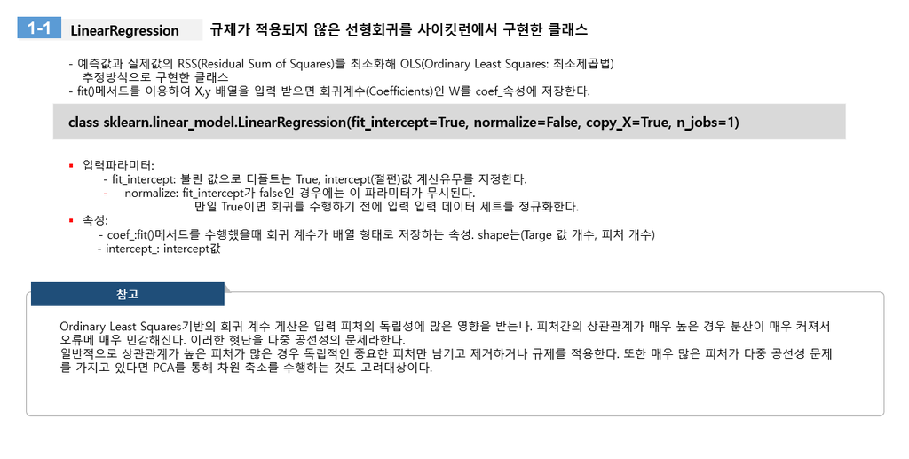

## [회귀평가지표]

- MAE
- MSE
- RMSE
- R^2

## [사이킷런의 회귀평가지표]

-사이킷런에서 RMSE를 구하려면 MSE에 제곱근을 씌워서 계산하는 함수를 직접 만들어야 함.

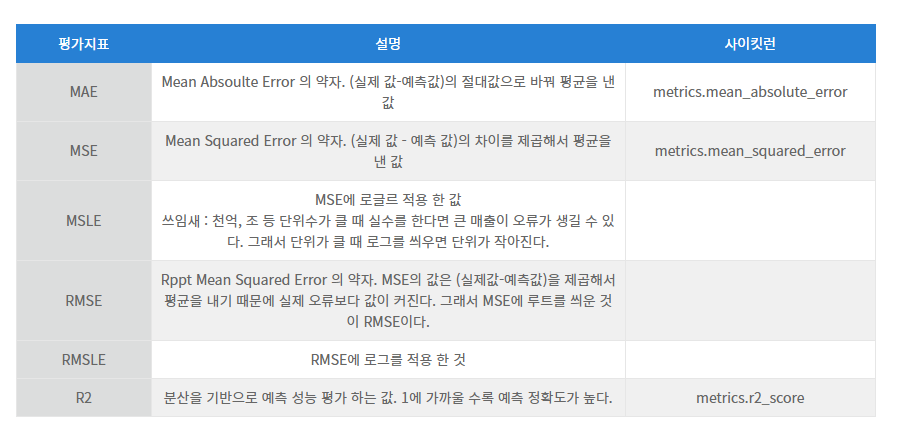

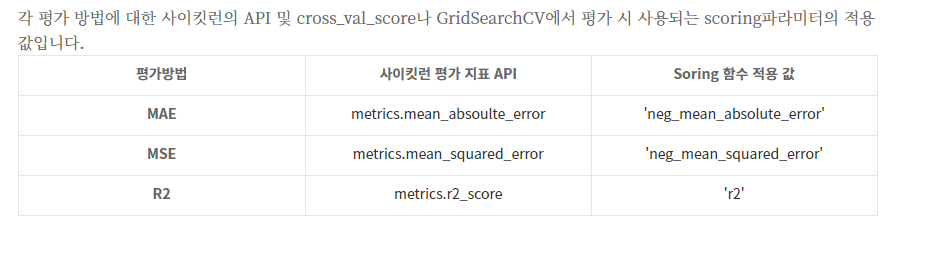

```python
import numpy as np
import matplotlib.pyplot as plt
import pandas as pd
import seaborn as sns
from sklearn.datasets import load_boston
```

## [참고: 사이킷런 데이터 셋]

- https://teddylee777.github.io/scikit-learn/Sklearn-dataset-%EB%AA%A8%EB%93%88%EC%9D%84-%ED%99%9C%EC%9A%A9%ED%95%98%EC%97%AC-dataset%EB%A1%9C%EB%94%A9%ED%95%98%EA%B8%B0
- boston.keys() 데이터셋을 로딩하고 나서 가능함.

[output not shown]

```python
# 보스턴 데이터셋 로딩
boston=load_boston()
boston_df=pd.DataFrame(boston.data,columns=boston.feature_names)

boston_df['price']=boston.target
boston_df

# CRIM: 지역별 범죄발생율
# zn: 25,000평방피트를 초과하는 거주 지역의 비율
# indus: 비상업 지역 넓이 비율
# chas: 찰스강에 대한 더미변수(강의 경계에 위치한 경우는 1, 아니면 0)
# nox: 일산화질소 농도
# rm: 거주할수 있는 방의 개수
# AGE: 1940년 이전에 건축된 소유주택의 비율
# dis: 5개 주요 고용센터까지의 가중 거리
# rad: 고속도로 접근 용이도
# tax: 10,000 달러당 재산 비율
# ptratio: 지역의 교사와 학생수 비율
# b: 지역의 흑인 거주 비율  / lstat: 하위계층의 비율
# medv: 본인 소유의 주택 가격(중앙값)
# price: 주택가격(y)
```

|  | CRIM | ZN | INDUS | CHAS | NOX | RM | AGE | DIS | RAD | TAX | PTRATIO | B | LSTAT | price |
| --- | --- | --- | --- | --- | --- | --- | --- | --- | --- | --- | --- | --- | --- | --- |
| 0 | 0.00632 | 18.0 | 2.31 | 0.0 | 0.538 | 6.575 | 65.2 | 4.0900 | 1.0 | 296.0 | 15.3 | 396.90 | 4.98 | 24.0 |
| 1 | 0.02731 | 0.0 | 7.07 | 0.0 | 0.469 | 6.421 | 78.9 | 4.9671 | 2.0 | 242.0 | 17.8 | 396.90 | 9.14 | 21.6 |
| 2 | 0.02729 | 0.0 | 7.07 | 0.0 | 0.469 | 7.185 | 61.1 | 4.9671 | 2.0 | 242.0 | 17.8 | 392.83 | 4.03 | 34.7 |
| 3 | 0.03237 | 0.0 | 2.18 | 0.0 | 0.458 | 6.998 | 45.8 | 6.0622 | 3.0 | 222.0 | 18.7 | 394.63 | 2.94 | 33.4 |
| 4 | 0.06905 | 0.0 | 2.18 | 0.0 | 0.458 | 7.147 | 54.2 | 6.0622 | 3.0 | 222.0 | 18.7 | 396.90 | 5.33 | 36.2 |
| ... | ... | ... | ... | ... | ... | ... | ... | ... | ... | ... | ... | ... | ... | ... |
| 501 | 0.06263 | 0.0 | 11.93 | 0.0 | 0.573 | 6.593 | 69.1 | 2.4786 | 1.0 | 273.0 | 21.0 | 391.99 | 9.67 | 22.4 |
| 502 | 0.04527 | 0.0 | 11.93 | 0.0 | 0.573 | 6.120 | 76.7 | 2.2875 | 1.0 | 273.0 | 21.0 | 396.90 | 9.08 | 20.6 |
| 503 | 0.06076 | 0.0 | 11.93 | 0.0 | 0.573 | 6.976 | 91.0 | 2.1675 | 1.0 | 273.0 | 21.0 | 396.90 | 5.64 | 23.9 |
| 504 | 0.10959 | 0.0 | 11.93 | 0.0 | 0.573 | 6.794 | 89.3 | 2.3889 | 1.0 | 273.0 | 21.0 | 393.45 | 6.48 | 22.0 |
| 505 | 0.04741 | 0.0 | 11.93 | 0.0 | 0.573 | 6.030 | 80.8 | 2.5050 | 1.0 | 273.0 | 21.0 | 396.90 | 7.88 | 11.9 |

506 rows × 14 columns

```python
boston_df.info()
```

```
<class 'pandas.core.frame.DataFrame'>
RangeIndex: 506 entries, 0 to 505
Data columns (total 14 columns):
 #   Column   Non-Null Count  Dtype
---  ------   --------------  -----
 0   CRIM     506 non-null    float64
 1   ZN       506 non-null    float64
 2   INDUS    506 non-null    float64
 3   CHAS     506 non-null    float64
 4   NOX      506 non-null    float64
 5   RM       506 non-null    float64
 6   AGE      506 non-null    float64
 7   DIS      506 non-null    float64
 8   RAD      506 non-null    float64
 9   TAX      506 non-null    float64
 10  PTRATIO  506 non-null    float64
 11  B        506 non-null    float64
 12  LSTAT    506 non-null    float64
 13  price    506 non-null    float64
dtypes: float64(14)
memory usage: 55.4 KB
```

```python
boston_df.isna().sum()
```

```
CRIM       0
ZN         0
INDUS      0
CHAS       0
NOX        0
RM         0
AGE        0
DIS        0
RAD        0
TAX        0
PTRATIO    0
B          0
LSTAT      0
price      0
dtype: int64
```

```python
# 각변수와 price 변수간의 상관도 분석
```

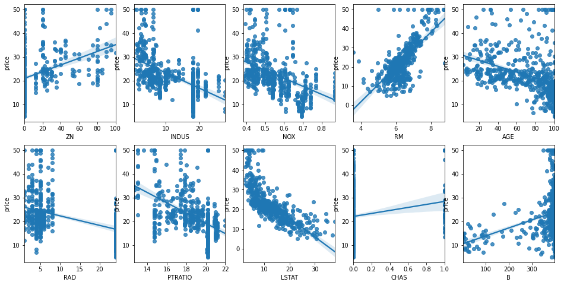

```python
# RM(거주할수 있는 방의갯수)하고 LSTA(하위 계층의 비율)가 price에 영향을 많이 미침
fig, axs = plt.subplots(figsize=(16,8), ncols=5, nrows=2)
lm_features = ['ZN', 'INDUS', 'NOX', 'RM', 'AGE', 'RAD','PTRATIO', 'LSTAT','CHAS','B']

for i, feature in enumerate(lm_features):
    row = int(i//5)
    col = i%5
    sns.regplot(x=feature, y='price', data=boston_df, ax=axs[row][col])
plt.show()
```

```python
# price를 제외한 모든 컬럼과의 상관도를 2행에서 표시하려함
# 단 행은 2로 지정되지만
# 열의 갯수는 자동으로 계산하게함

# 열이 6개 있으면  2행3열 차트
# 열이 12개가 있으면 2행 6열 차트가 나올수 있도록 함.
```

[output not shown]

```python
# 트레이닝 데이터하고 테스트 데이터를 분리하고 학습/예측/평가 수행
```

```python
# x, y값 분리
# x,y 값을 트레이닝하고 테스트로 나누어줌
# 회귀분석을 실행
# fit()함
# 성공율등을 확인함
from sklearn.model_selection import train_test_split
from sklearn.linear_model import LinearRegression
from sklearn.metrics import mean_squared_error , r2_score  #회귀평가지표
```

```python
y_target=boston_df['price']
X_data=boston_df.drop(['price'],axis=1,inplace=False)
```

```python
X_train , X_test , y_train , y_test = train_test_split(X_data , y_target ,
                                                       test_size=0.3, random_state=156)
```

```python
# Linear Regression 실행(OLS로 학습하여 예측/평가하고자함)
lr = LinearRegression()
lr.fit(X_train ,y_train )
y_preds = lr.predict(X_test)
mse=mean_squared_error(y_test,y_preds)
rmse=np.sqrt(mse)
r2=r2_score(y_test,y_preds) #설명력

print('회귀평가척도 MSE: {0:.4f},  MSE의제곱근 RMSE: {1:.4f}'.format(mse,rmse))
print('결정계수 R2: {0: .4f}'.format(r2))
```

```
회귀평가척도 MSE: 17.2969,  MSE의제곱근 RMSE: 4.1590
결정계수 R2:  0.7572
```

```python
print(lr.intercept_)

# 첫번째 나온 -0.1은 첫번째 특징값의 CRIM의 회귀계수 (W1)
# 두번째 나온 0.1은 두번째 특징 ZM의 회귀계수(W2)
print(np.round(lr.coef_,1))
```

```
40.995595172164336
[ -0.1   0.1   0.    3.  -19.8   3.4   0.   -1.7   0.4  -0.   -0.9   0.
  -0.6]
```

```python
boston_df.info()
```

```
<class 'pandas.core.frame.DataFrame'>
RangeIndex: 506 entries, 0 to 505
Data columns (total 14 columns):
 #   Column   Non-Null Count  Dtype
---  ------   --------------  -----
 0   CRIM     506 non-null    float64
 1   ZN       506 non-null    float64
 2   INDUS    506 non-null    float64
 3   CHAS     506 non-null    float64
 4   NOX      506 non-null    float64
 5   RM       506 non-null    float64
 6   AGE      506 non-null    float64
 7   DIS      506 non-null    float64
 8   RAD      506 non-null    float64
 9   TAX      506 non-null    float64
 10  PTRATIO  506 non-null    float64
 11  B        506 non-null    float64
 12  LSTAT    506 non-null    float64
 13  price    506 non-null    float64
dtypes: float64(14)
memory usage: 55.4 KB
```

```python
#회귀계수가 높은 순으로 자료를 나열하여 봅니다.
coeff_=pd.Series(data=np.round(lr.coef_,1),index=X_data.columns)
coeff_.sort_values(ascending=False)

# 가장큰 회귀계수(가중치)는 rm(방개수), chas(찰스강에 경계에 위치하면 1, 아니면 0)
# RAD: 고속도로 접근 용이성
# NOX: 일산화질소 농도, DIS: 5개주요 고용센터까지의 가중 거리
```

```
RM          3.4
CHAS        3.0
RAD         0.4
ZN          0.1
INDUS       0.0
AGE         0.0
TAX        -0.0
B           0.0
CRIM       -0.1
LSTAT      -0.6
PTRATIO    -0.9
DIS        -1.7
NOX       -19.8
dtype: float64
```

### [k겹교차검증]

- 506개의 적은 자료를 가지고 데이터분석을 실행할때 k개만큼 자료를 교차해서 검증해야 함.
- https://davinci-ai.tistory.com/18

```python
from sklearn.model_selection import cross_val_score
```

```python
y_target=boston_df['price']
X_data=boston_df.drop(['price'],axis=1,inplace=False)
lr=LinearRegression()
```

```python
cross_score = cross_val_score(lr, X_data, y_target,
                              scoring='neg_mean_squared_error', cv=5)
rmse_score = np.sqrt(-1*cross_score)
rmse_mean = rmse_score.mean()
rmse_std = rmse_score.std()

print(rmse_mean)
print(np.round(rmse_score,2))
```

```
5.828658946215813
[3.53 5.1  5.75 8.99 5.77]
```

## 다항회귀는 선형일까요? 비선형일까요?

- 특징값(X,독립변수)가 다항식을 비선형이라고 하지 않고
- 회귀계수(W)가 다항식일때를 비선형이라고 함.
- 회귀계수를 다항식으로 만든것이 오류율이 작음
- 단 과대적합 확률이 많음
- 사이킷런에서는 다항회귀를 위한 클래스를 제공하지 않음
- 사이킷런의 PolymomialFeatures 클래스를 이용해서 피처를 다항식으로 변환하고 degree 파라미터를 통해 단항식 피터를 몇개의 다항식으로 변환할지를 결정

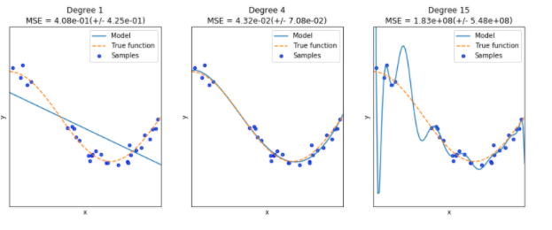

### [편향-분산 트레이드오프]

-https://bkshin.tistory.com/entry/%EB%A8%B8%EC%8B%A0%EB%9F%AC%EB%8B%9D-12-%ED%8E%B8%ED%96%A5Bias%EC%99%80-%EB%B6%84%EC%82%B0Variance-Trade-off

- 아래그림의 1번그림 저편향/저분산은 예측결과가 실제결과에 매우 근접하면서도 예측 변동성이 크지 않고 특정 부분에 집중돼 있는 뛰어난 성능을 보임
- 저편향/고분산은 예측결과가 실제 데이터에 매우 근접하지만 예측결과가 실제 데이터 결과를 중심으로 큰 폭으로 분포되어 있음.
- 일반적으로 편향과 분산은 한쪽이 높으면 한쪽이 낮아지는 경향이 있으면.
- 편향이 높으면 분산이 낮아짐(과소적합), 분산이높고 편향이 낮으면(과대적합)
- 편향을 높이면 전체오류가 높아짐, 편향을 점점 낮추면 분산이 높아지고, 전체 오류도 낮아짐
- 편향을 낮추고 분산을 높이면서 전체 오류를 가장 낮아지게 하는 지점인 '골디락스'지점을 통과하면서 분산을 지속적으로 높이면 전체 오류값이 오히려 증가하여 예측 성능성이 다시 저하됨
- 분산과 편향은 서로 트레이드오프를 이루면서 오류 cost값이 최대로 낮아지는 모델을 구축하는 것이 가장 효율적인 머신러닝 예측 모델을 만드는 방법임

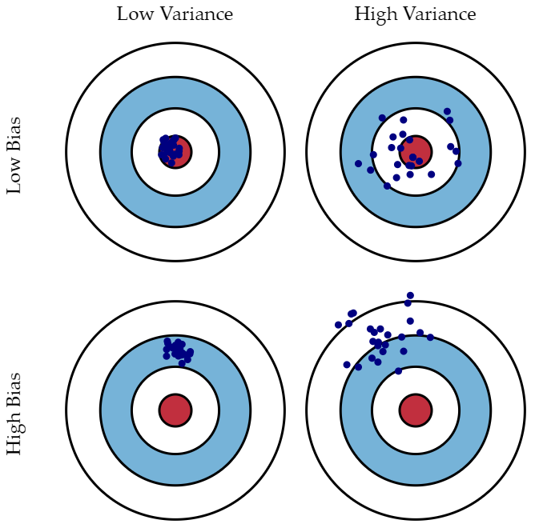

## 규제선형 모델-릿지, 라쏘, 엘라스틱넷

- https://light-tree.tistory.com/125
- 일차항인 경우 과소적합이 일어날수 있고, 다차항인 경우는 다항식이 복잡해지고 회귀계수가 매우 크게 설정이 되면서 과대적합이 일어날수 있음.
- 회귀식 모델은 적절히 데이터에 적합하면서도 회귀 계수가 기하급수적으로 커지는 것을 제어할수 있어야함.
- 선형모델의 비용함수에서 RSS를 최소화(실제값과 예측값의 차이 최소화)하는 것만 고려하다보니 학습 데이터에 지나치게 맞추게 되고, 회귀 계수가 쉽게 커지는 과대적합이 생김. 이를 반영해 비용함수는 학습 데이터의 잔차 오류값을 최소로 하는 RSS 최소화 방법과 과적합을 방지하기 위해 회귀계수의 값이 커지지 않도록 하는 방법이 서로 균형을 이루어야 함.

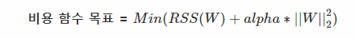

### [노름]

- 선형대수학에서 놈은 벡터의 크기(magnitude) 또는 길이(length)를 측정하는 방법을 의미
- 차원(dimension)과 길이(length)는 다름

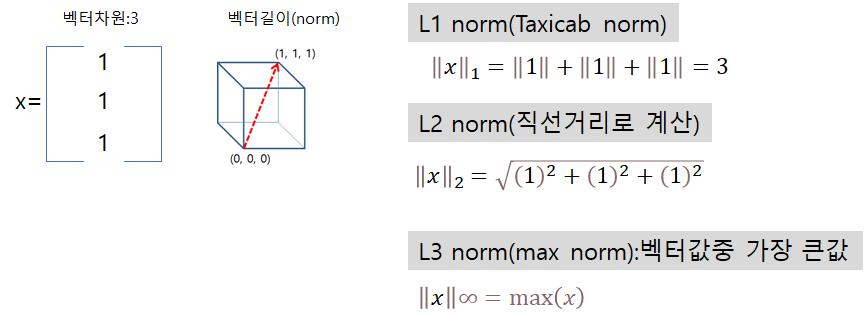

- 1. 일반 선형 회귀: 예측값과 실제값의 RSS( Residual Sum of Squares )를 최소화할 수 있도록 회귀 계수를 최적화하며

- 1. 릿지( Ridge ): 선형 회귀에 L2규제를 추가한 회귀 모델. L2규제는 상대적으로 큰 회귀 계수 값의 예측 영향도를 감소시키기 위해서 회귀 계수값을 더 작게 만드는 규제 모델.
- 1. 라쏘( Lasso ): 선형 회귀에 L1규제를 적용한 회귀 모델. L1규제는 예측 영향력이 작은 피처의 회귀 계수를 0으로 만들어 회귀 예측 시 피처가 선택되지 않게 하는 것.
- 1. 엘라스틱넷( ElasticNet ): L2, L1 규제를 함께 결합한 모델로 주로 피처가 많은 데이터 세트에 적용되며, L1규제로 피처의 개수를 줄임과 동시에 L2규제로 계수 값의 크기를 조정합니다.
- 1. 로지스틱 회귀( Logistic Regression ) : 분류에 사용되는 선형 모델로 매우 강력한 분류 알고리즘입니다.

```python
# https://bskyvision.com/193
# https://light-tree.tistory.com/125
```

## [릿지모델(L2규제)]

```python
#보스턴데이터셋을 불러와서
# boston_df를 구성하고 그중에 price값은 y_target으로
# 그외 나머지 변수는 X_data로 할당

from sklearn.linear_model import Ridge
ridge=Ridge(alpha=10)


cross_score = cross_val_score(ridge, X_data, y_target,
                              scoring='neg_mean_squared_error', cv=5)
rmse_score = np.sqrt(-1*cross_score)
rmse_mean = rmse_score.mean()


print(' 5 folds 의 개별 Negative MSE scores: ', np.round(cross_score, 3))
print(' 5 folds 의 개별 RMSE scores : ', np.round(rmse_score,3))
print(' 5 folds 의 평균 RMSE : {0:.3f} '.format(rmse_mean))
```

```
 5 folds 의 개별 Negative MSE scores:  [-11.422 -24.294 -28.144 -74.599 -28.517]
 5 folds 의 개별 RMSE scores :  [3.38  4.929 5.305 8.637 5.34 ]
 5 folds 의 평균 RMSE : 5.518
```

```python
#알파값 변경
alphas=[0,0.1,1,10,100]

for i in alphas:
    ridge=Ridge(alpha=i)
    cross_score = cross_val_score(ridge, X_data, y_target,
                                  scoring='neg_mean_squared_error', cv=5)
    rmse_score = np.sqrt(-1*cross_score)
    rmse_mean = rmse_score.mean()
    print('알파값이 {0} 일때=> 5 folds 의 평균 RMSE : {1:.3f} '
          .format(i,rmse_mean))
```

```
알파값이 0 일때=> 5 folds 의 평균 RMSE : 5.829
알파값이 0.1 일때=> 5 folds 의 평균 RMSE : 5.788
알파값이 1 일때=> 5 folds 의 평균 RMSE : 5.653
알파값이 10 일때=> 5 folds 의 평균 RMSE : 5.518
알파값이 100 일때=> 5 folds 의 평균 RMSE : 5.330
```

```python
# 데이터프레임으로 알파값의 변화에 따르는 회귀계수의 값을
# 출력하여 봅니다.

# 참고, 리지값에서 회귀계수값 확인
ridge=Ridge(alpha=100)
ridge.fit(X_data, y_target)
#np.round(ridge.coef_,3)

#회귀계수를나열하여 봅니다.
coeff_=pd.Series(data=np.round(ridge.coef_,1),index=X_data.columns)
coeff_.sort_values(ascending=False)
```

```
RM         2.3
CHAS       0.6
RAD        0.3
ZN         0.1
AGE        0.0
TAX       -0.0
B          0.0
CRIM      -0.1
INDUS     -0.1
NOX       -0.3
LSTAT     -0.7
PTRATIO   -0.8
DIS       -1.2
dtype: float64
```

## [랏쏘모델(L1규제)]

- L2규제에 비해 회귀계수가 급격하게 0으로 되는 경향이 있음.
- L1규제는 적절한 피처값만 사용하는 것을 권장함 -랏쏘모델의 특징: 서로 상관관계가 높은 피처들의 경우 이들중에서 중요한 피처만 선택하고나머지 피처는 회귀계수를 0으로 만드는 성향이 강함. 이러한 이유로 알파값에 따른 회귀계수의 값이 급격하게 변동할 수 있음